# Problem 1.

```python
import pandas as pd
import numpy as np
import matplotlib as mpt
import matplotlib.pyplot as plt
import seaborn as sns

rawData = pd.read_csv('baseball.csv')
```

```python
#find high number of null values
rawData.isna().sum()
```

```
Team              0
League            0
Year              0
RS                0
RA                0
W                 0
OBP               0
SLG               0
BA                0
Playoffs          0
RankSeason      988
RankPlayoffs    988
G                 0
OOBP            812
OSLG            812
dtype: int64
```

```python
#remove columns with null values
data = rawData.drop(['RankSeason', 'RankPlayoffs', 'OOBP', 'OSLG'], 1)
data.isna().sum()
```

```
Team        0
League      0
Year        0
RS          0
RA          0
W           0
OBP         0
SLG         0
BA          0
Playoffs    0
G           0
dtype: int64
```

```python
#look at corrilation table
corr = data.corr('pearson', 1)
corr
```

|  | Year | RS | RA | W | OBP | SLG | BA | Playoffs | G |
| --- | --- | --- | --- | --- | --- | --- | --- | --- | --- |
| Year | 1.000000 | 0.418978 | 0.412020 | 0.004138 | 0.374354 | 0.536037 | 0.349397 | 0.145779 | 0.009287 |
| RS | 0.418978 | 1.000000 | 0.380139 | 0.511745 | 0.900492 | 0.918740 | 0.827000 | 0.386628 | 0.075195 |
| RA | 0.412020 | 0.380139 | 1.000000 | -0.532394 | 0.326360 | 0.436527 | 0.330764 | -0.261477 | -0.023369 |
| W | 0.004138 | 0.511745 | -0.532394 | 1.000000 | 0.481836 | 0.401496 | 0.408716 | 0.616757 | 0.105309 |
| OBP | 0.374354 | 0.900492 | 0.326360 | 0.481836 | 1.000000 | 0.790910 | 0.851958 | 0.363890 | 0.016563 |
| SLG | 0.536037 | 0.918740 | 0.436527 | 0.401496 | 0.790910 | 1.000000 | 0.790481 | 0.324713 | 0.036770 |
| BA | 0.349397 | 0.827000 | 0.330764 | 0.408716 | 0.851958 | 0.790481 | 1.000000 | 0.290217 | 0.019886 |
| Playoffs | 0.145779 | 0.386628 | -0.261477 | 0.616757 | 0.363890 | 0.324713 | 0.290217 | 1.000000 | 0.022208 |
| G | 0.009287 | 0.075195 | -0.023369 | 0.105309 | 0.016563 | 0.036770 | 0.019886 | 0.022208 | 1.000000 |

## a)

The two most negatively correlated variables are regular-season wins in the year and runs allowed by the team in the year.

## b)

The number of runs scored and the slugging percentage of the team for are the two most highly correlated variables.

## d)

There are 1s in the diagonal since the algorithm is checking a variable's correlation with itself.

# Problem 2.

## a)

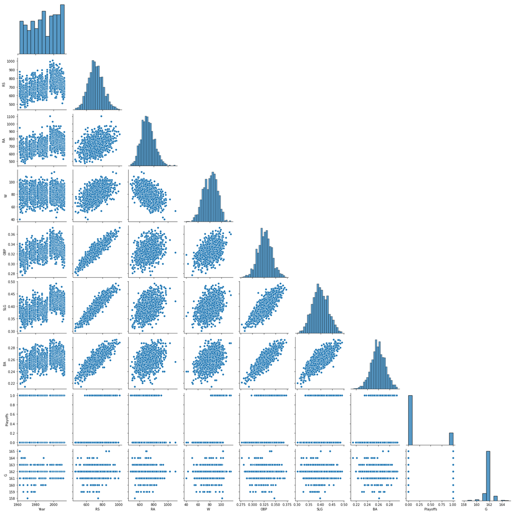

```python
pplot = sns.pairplot(data, corner=True)
pplot
```

The plots with the highest Pearson correlation look like a '/', while the variables with the most negative correlation look like a '\ ', and the plots with the least correlation at all look like a circle.

## b)

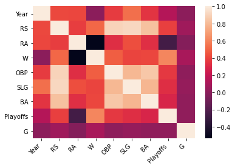

```python
hmap = sns.heatmap(corr)
hmap.set_xticklabels(hmap.get_xticklabels(),
                     rotation=45,
                     horizontalalignment='right')
hmap
```

Most variables have a positive correlation which leads me to assume most variables are stats that are good for winning the game. Going with that I see that all most three variables (Year, Runs allowed, and Games played) that are correlated with wins are either not correlated or negatively correlated telling me that those are the only three variables not good for winning.

# Problem 3.

## a)

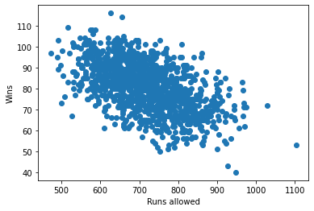

```python
plt.scatter(data.RA, data.W)
plt.xlabel('Runs allowed')
plt.ylabel('Wins')
plt.show()
```

I think Wins are the dependent variable since the more runs allowed the less wins the teams have in general (and they have a negative correlation).

## b)

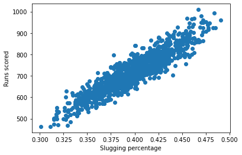

```python
plt.scatter(data.SLG, data.RS)
plt.xlabel('Slugging percentage')
plt.ylabel('Runs scored')
plt.show()
```

I think runs scored is dependant on the slugging percentage.

# Problem 4.

## a)

```python
import statsmodels.api as sm

y = data.W
x = data.RA
x = sm.add_constant(x)
model = sm.OLS(y,x)
res = model.fit()
p = res.params
print(p)
print(res.summary())
```

```
const    127.769033
RA        -0.065538
dtype: float64
                            OLS Regression Results
==============================================================================
Dep. Variable:                      W   R-squared:                       0.283
Model:                            OLS   Adj. R-squared:                  0.283
Method:                 Least Squares   F-statistic:                     486.5
Date:                Fri, 16 Oct 2020   Prob (F-statistic):           4.06e-91
Time:                        00:05:15   Log-Likelihood:                -4546.8
No. Observations:                1232   AIC:                             9098.
Df Residuals:                    1230   BIC:                             9108.
Df Model:                           1
Covariance Type:            nonrobust
==============================================================================
                 coef    std err          t      P>|t|      [0.025      0.975]
------------------------------------------------------------------------------
const        127.7690      2.143     59.634      0.000     123.566     131.973
RA            -0.0655      0.003    -22.058      0.000      -0.071      -0.060
==============================================================================
Omnibus:                        5.903   Durbin-Watson:                   1.843
Prob(Omnibus):                  0.052   Jarque-Bera (JB):                5.615
Skew:                          -0.127   Prob(JB):                       0.0604
Kurtosis:                       2.789   Cond. No.                     5.59e+03
==============================================================================

Notes:
[1] Standard Errors assume that the covariance matrix of the errors is correctly specified.
[2] The condition number is large, 5.59e+03. This might indicate that there are
strong multicollinearity or other numerical problems.
```

## b)

```python
z = data.RS
w = data.SLG
w = sm.add_constant(w)
model2 = sm.OLS(z,w)
res2 = model2.fit()
print(res2.params)
print(res2.summary())
```

```
const    -289.367958
SLG      2527.924670
dtype: float64
                            OLS Regression Results
==============================================================================
Dep. Variable:                     RS   R-squared:                       0.844
Model:                            OLS   Adj. R-squared:                  0.844
Method:                 Least Squares   F-statistic:                     6659.
Date:                Fri, 16 Oct 2020   Prob (F-statistic):               0.00
Time:                        00:05:15   Log-Likelihood:                -6167.4
No. Observations:                1232   AIC:                         1.234e+04
Df Residuals:                    1230   BIC:                         1.235e+04
Df Model:                           1
Covariance Type:            nonrobust
==============================================================================
                 coef    std err          t      P>|t|      [0.025      0.975]
------------------------------------------------------------------------------
const       -289.3680     12.352    -23.426      0.000    -313.602    -265.134
SLG         2527.9247     30.979     81.602      0.000    2467.147    2588.702
==============================================================================
Omnibus:                       13.895   Durbin-Watson:                   1.724
Prob(Omnibus):                  0.001   Jarque-Bera (JB):               14.037
Skew:                           0.251   Prob(JB):                     0.000895
Kurtosis:                       3.148   Cond. No.                         34.8
==============================================================================

Notes:
[1] Standard Errors assume that the covariance matrix of the errors is correctly specified.
```